# Assessment

Vishal

2022-12-14

## Section B

### B.1

#### (1)

Let’s consider,
$$\mathcal{p} = \text{probability that light bulb comes from line A}\\
\mathcal{p_A} = \text{probability that the light bulb has a lifetime
equal to or greater than 2 years given it is produced in Line A}\\
\mathcal{p_B} = \text{probability that the light bulb has a lifetime
equal to or greater than 2 yeas given it is produced in Line B}\\
\alpha = \text{probability that the light bulb is made in line B, given
that it's lifetime is less than 2 years.}$$
We need to calculate the probability that the light bulb is manufactured from line B, provided it’s lifetime is less than 2 years. i.e. $\alpha$.

Let’s assume that $\mathcal{p_D} = \text{probability that light bulb has life time less than 2 years.}$

So, $\alpha = \mathbb{P}(B|D) \text{ i.e. probability that the light bulb is made in line B, given that it's lifetime is less than 2 years.}$

We know that,
$$\alpha = \mathbb{P}(B|D)
\Rightarrow \frac{\mathbb{P}(B \cap D)}{\mathbb{P}(D)}$$
$$\Rightarrow \frac{\mathbb{P}(B)
\mathbb{P}(D|B)}{\mathbb{P}(A)\mathbb{P}(D|A) +
\mathbb{P}(B)\mathbb{P}(D|B)}$$

$$\Rightarrow \boxed{\frac{(1-\mathcal{p})(1 -
\mathcal{p_B})}{\mathcal{p}(1 - \mathcal{p_A}) + (1 - \mathcal{p})(1 -
\mathcal{p_B})}} \tag{1}$$
#### (2) We have,
$$\mathcal{p_A} = 0.99\\
\mathcal{p_B} = 0.5\\
\mathcal{p} = 0.1$$

And we need to calculate $\alpha$. Using equation (1), we get,
$$\Rightarrow \frac{(1-\mathcal{p})(1 - \mathcal{p_B})}{\mathcal{p}(1 -
\mathcal{p_A}) + (1 - \mathcal{p})(1 - \mathcal{p_B})} \\
\Rightarrow \frac{(1 - 0.1)(1 - 0.5)}{0.1(1 - 0.99) + (1 - 0.1)(1 -
0.5)}\\
\Rightarrow \frac{0.9 * 0.5}{0.1*0.01 + 0.9*0.5} \\
\Rightarrow \frac{0.45}{0.451} \\
\Rightarrow \boxed{0.9977827}$$
#### (3)

```r
n <- 100000
 df <- data.frame(Line = sample(c(0, 1), 100000, prob = c(0.1, 0.9), replace = T)) %>%
  mutate(LessThan2Years = case_when(Line == 0 ~sample(c(0, 1), n, prob = c(0.99, 0.01), replace = TRUE),
                                    (Line == 1 ~sample(c(0, 1), n, prob = c(0.5, 0.5), replace = TRUE))))
```

#### (4)

```r
lessThan2YearsDf <- df %>%
  filter(LessThan2Years == 1)

lessThan2YearsLine1 <- lessThan2YearsDf %>%
  filter(Line == 1) %>%
  count()

alpha = lessThan2YearsLine1 / length(lessThan2YearsDf$Line)
print(round(alpha, 5))
```

```
##         n
## 1 0.99773
```

## B.2

Let,
$$X = \text{continuous random variable} \\
X = 0, \text{product gets on the shelf immediately after it is sold out}$$
We have PDF given as,
$$\begin{equation}
\nonumber \mathcal{p_\lambda}(x) = \left\{
\begin{array}{l l}
ae^{-\lambda (x - b)} & \quad x \geq b\\
0 & \quad \textrm{if } x < b
\end{array} \right.
\end{equation}$$
where,
$$b > 0 \text{ is a known constant}\\
\lambda > 0 \text{ is a parameter of the distribution}$$

The given probability density function is a **memoryless** form of the exponential distribution function meaning, the distribution of time between restocking the shelves is the same as at time zero.  
So the function is similar as,

$$\begin{equation}
\nonumber \mathcal{p_\lambda}(x) = \left\{
\begin{array}{l l}
ae^{-\lambda (x)} & \quad x > 0\\
0 & \quad otherwise
\end{array} \right.
\end{equation}$$
Integrating this function, we will get,
$$\mathcal{p_\lambda}(x)
= -\dfrac{a\mathrm{e}^{-\lambda\cdot\left(x-b\right)}}{\lambda}\\$$
$$\Rightarrow \dfrac{a\cdot\left(\mathrm{e}^{b\lambda}-1\right)}{\lambda}
\tag{1}$$

#### (1)

To derive the value of $a$, we need to integrate the function while the value is 1.
From equation (1), we have,
$$\int_{0}^{\infty}
\mathcal{p_\lambda}(x) =
\dfrac{a\cdot\left(\mathrm{e}^{b\lambda}-1\right)}{\lambda}\\
1 = \dfrac{a\cdot\left(\mathrm{e}^{b\lambda}-1\right)}{\lambda}\\
a = \frac{\lambda}{(\mathrm{e}^{b\lambda}-1)}$$

#### 2

**Population mean:**
We’ll be using integration by parts to find the population mean.
$$EX = \int_{0}^{\infty} a e^{- \lambda (x - b)}xdx$$
$$\Rightarrow
-\dfrac{a\cdot\left(t\mathrm{e}^{b\lambda}x+\mathrm{e}^{b\lambda}\right)\mathrm{e}^{-\lambda
x}}{\lambda^2}\\
\Rightarrow -\dfrac{a\cdot\left(\lambda
x+1\right)\mathrm{e}^{b\lambda-\lambda x}}{\lambda^2}\\
\Rightarrow \dfrac{a\mathrm{e}^{b\lambda}}{\lambda^2}$$
**Standard Deviation:**
$$\sigma^2 = E((X - \mu) ^ 2) \\
\Rightarrow E((X - E(X)) ^ 2) \\
\Rightarrow \int_{0}^{\infty}
-\dfrac{a\mathrm{e}^{-\lambda\cdot\left(x-b\right)}}{\lambda} -
\dfrac{a\mathrm{e}^{b\lambda}}{\lambda^2} \\
\Rightarrow \dfrac{a\cdot\left(\mathrm{e}^{b\lambda}-1\right)}{\lambda}
- \dfrac{a\mathrm{e}^{b\lambda}}{\lambda^2} \\
\Rightarrow \frac{a(\lambda e^{b\lambda} - e^{b\lambda} -
\lambda)}{\lambda}$$

#### (3)

**Cumulative Distribution function:**
$$\int_{-\infty}^{0}f(t)dt = \int_{-\infty}^{0}f(t)dt +
\int_{0}^{x}f(t)dt\\
\Rightarrow \int_{-\infty}^{0}0dt + \int_{0}^{x}ae^{-\lambda(t - b)}dt\\
\Rightarrow
a\cdot\left(\dfrac{\mathrm{e}^{b{\lambda}}}{{\lambda}}-\dfrac{\mathrm{e}^{b{\lambda}-x{\lambda}}}{{\lambda}}\right)
\\
\Rightarrow
\dfrac{a\cdot\left(\mathrm{e}^{x{\lambda}}-1\right)\mathrm{e}^{b{\lambda}-x{\lambda}}}{{\lambda}}
\\
\Rightarrow -\dfrac{a \cdot (e ^ {-\lambda x + \lambda b} - e ^ {\lambda
b})}{\lambda}$$

**Quantile function:**  
The quantile function $\mathcal{Q_X}(p)$ is defined as the samllest $x$ such that ${F_X}(x) = p$

$$Q_X(p) = min{\{x \in \mathbb{R} | F_X(x) = p\}} \tag{a}$$

Thus we have $Q_X(p) = -\infty, \text{ if } p = 0. \text{ When } p > 0, \text{ it holds that }$,

$$Q_X(p) = F_X^{-1}(x) \tag{b}$$

Arranging the probability density function we get,
$$p = ae^{-\lambda(x - b)} \\
\Rightarrow \frac{p}{a} = e^{-\lambda(x - b)} \\
\Rightarrow \ln \frac{p}{a} = -\lambda(x - b) \\
\Rightarrow \ln \frac{p}{a} = -\lambda x + \lambda b \\
\Rightarrow \lambda x = \lambda b - \ln \frac{p}{a} \\
\Rightarrow x = \frac{\lambda b - \ln \frac{p}{a}}{\lambda} \\
\Rightarrow x = \frac{\lambda b - \ln {p} + \ln {a}}{\lambda} \\$$

#### (4)

**Maximum Likelihood Estimate:**

$$\lambda_{MLE} = \prod_{i = 1}^{n}f_X(x_i; \lambda) = \prod_{i = 1}^{n}
\bigl\{{ae^{-\lambda(x_i - b)}}\bigr\} \\
L(\lambda) = ae^{-n\lambda((x_1 + x_2 + ... + x_n) - b)} \\
\log L(\lambda) = \log (a) - \lambda x log(e) + \lambda b \log(e) \\
\text{Taking derivative on both sides,} \\
\frac{d}{d\lambda} \{\log L(\lambda)\} = \frac{d}{d\lambda} \{\log (a) -
\lambda x log(e) + \lambda b \log(e)\} \\
\frac{1}{\lambda} = b - \bar x \\
\lambda = \frac{1}{b - \bar x}\\
\text{## Should be bn - x }$$

```r
supermarketDataDf <- read.csv("supermarket_data_EMATM0061.csv")
head(supermarketDataDf)
```

```
##   TimeLength
## 1   304.1401
## 2   504.4332
## 3   388.3975
## 4   326.7841
## 5   310.8762
## 6   340.0900
```

#### (5)

To calculate the MLE, we know that log MLE for the given function is $\frac{1}{b - \bar x}$.

```r
b = 300
MLE = 1 / (b - mean(supermarketDataDf$TimeLength))
MLE
```

```
## [1] -0.01988426
```

#### (6)

```r
compute_median <- function(df, indices, col_name) {
  sub_sample <- slice(df, indices) %>%
    pull(all_of(col_name))
  return(median(sub_sample, na.rm = T))
}
```

```r
results <- boot(data = supermarketDataDf, statistic = compute_median, col_name = "TimeLength", R = 10000)

boot.ci(boot.out = results, type = "perc", conf = 0.95)
```

```
## BOOTSTRAP CONFIDENCE INTERVAL CALCULATIONS
## Based on 10000 bootstrap replicates
##
## CALL :
## boot.ci(boot.out = results, conf = 0.95, type = "perc")
##
## Intervals :
## Level     Percentile
## 95%   (333.6, 337.8 )
## Calculations and Intervals on Original Scale
```

#### (7)

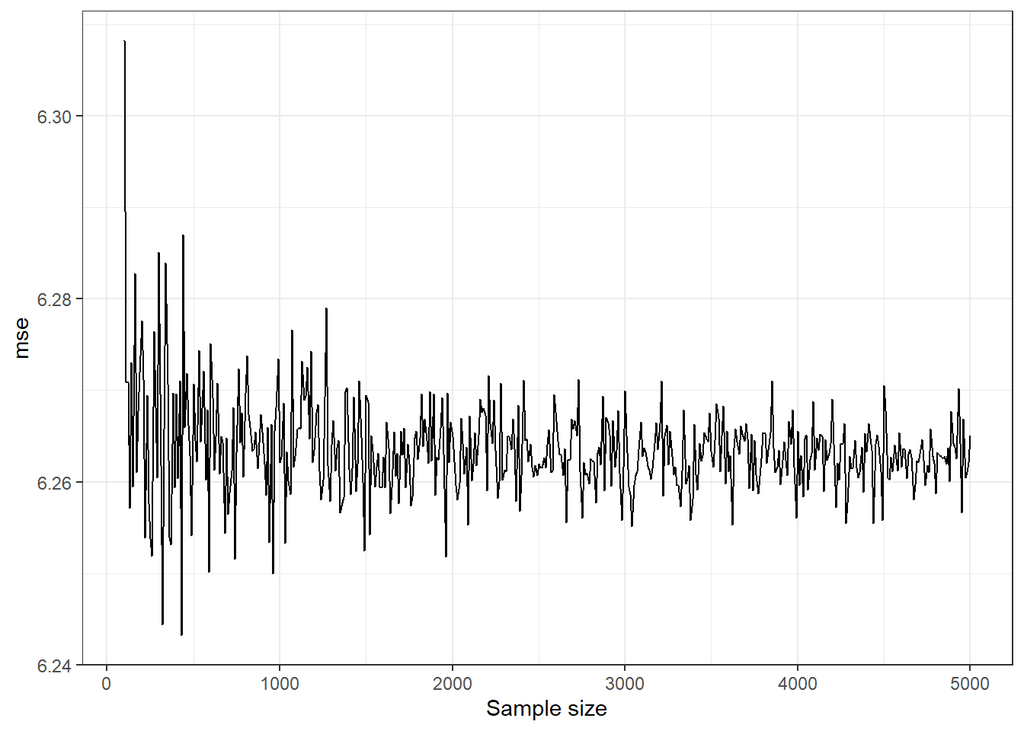

```r
b = 0.01
lambda_0 = 2
sample_size_seq <- seq(100, 5000, 10)
num_trials_per_size <- 100

compute_mle <- function(x, b) {
  return (1 / (b - mean(x)))
}

df <- crossing(sample_size = sample_size_seq, trials = seq(num_trials_per_size)) %>%
  mutate(samples = map(sample_size, ~rpois(.x, lambda_0))) %>%
  mutate(lambda_mle = map_dbl(samples, ~compute_mle(.x, b)))


df_mse <- df %>%
  group_by(sample_size) %>%
  summarise(mse = mean(lambda_mle - lambda_0) ^ 2)

ggplot(df_mse) +
  geom_line(aes(x = sample_size, y = mse)) +
  theme_bw() +
  xlab('Sample size')
```